# Late Exaggeration

## Conclusions

A late exaggeration of 4 is clearly way too large for the datasets looked at here. Either 1.5 or 2 seems much more appropriate. For these settings, we see the expected result of much smaller, better-separated clusters with little effect on the neighbor preservation values. The most suitable value seems dataset-dependent (as usual): to my eyes, `iris` and `oli` don’t benefit much from any late exaggeration, although maybe an exaggeration even more mild than 1.5 would help.

For the other datasets, these results are very reminiscent of the [UMAP](https://jlmelville.github.io/smallvis/umap.html) and [u-SNE](https://jlmelville.github.io/smallvis/umaptsne.html) results, but have the advantage of being faster and easier to optimize.

Finally, if late exaggeration and early exaggeration are useful, why not always be exaggerating? Below are results from applying a constant exaggeration with `exaggeration_factor = 1.5` by setting `stop_lying_iter = 1000`:

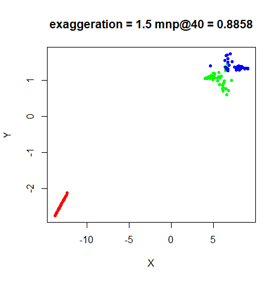

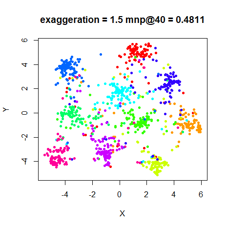

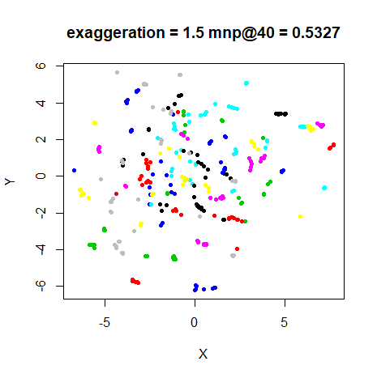

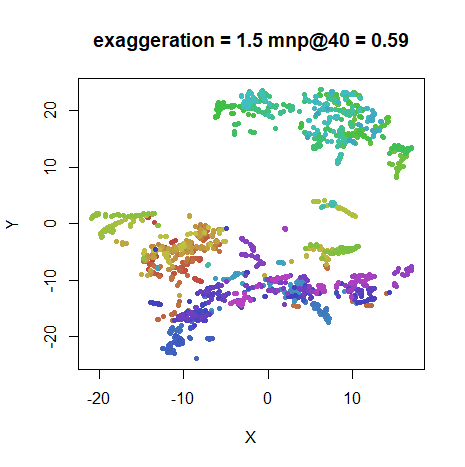

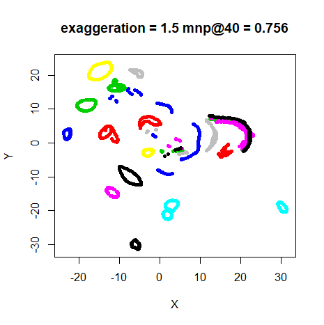

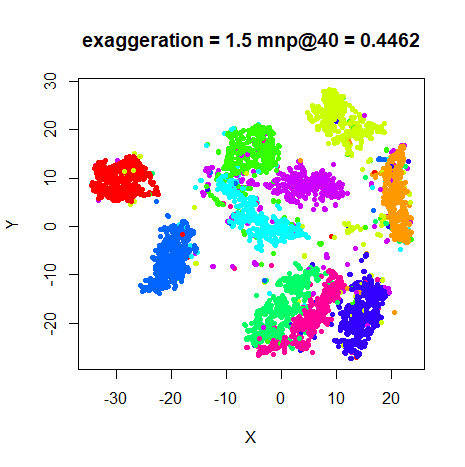

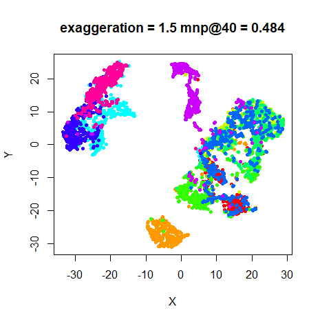

It seems that allowing a non-exaggerated phase of the optimization allows the clusters to re-arrange and spread out a bit, because the late-exaggeration results are more spread out (particularly noticeable if you look at the range on the axes), but these constant-exaggeration results look pretty good and still resemble a more-compressed version of the t-SNE results, although probably starting from the usually good scaled PCA initialization may have something to do with that.

If you find that t-SNE results are not separating clusters in your data in a good way, then it does seem that late exaggeration helps, but for the datasets that `smallvis` can deal with, I recommend an `exaggeration_factor` of around 1.5, much lower than the value of 12 mentioned in the FIt-SNE paper, and even 4 is much too large based on the results shown here.

## Momentum and exaggeration length

*February 24 2019* Here’s a little addendum to flesh out the discussion on late exaggeration:

Even with the reduced exaggeration, for all examples I looked at, the cost does increase over the last 100 iterations, suggesting that the learning rate or momentum values are too high for the late exaggeration phase.

Normally, `mom_switch_iter` is set to happen after early exaggeration finishes, so perhaps we should switch back to the lower momentum during late exaggeration?

Below are some examples where I modified the code to use the original `momentum` value during late exaggeration. I’ve also looked at using 250 iterations of early and late exaggeration, to see if our conclusions are affected by more exaggeration time. In the latter case, `max_iter = 1300`, so that the same amount of non-exaggeration optimization was carried out and also `mom_switch_iter = 350`, so that there was always 100 iterations of non-exaggerated optimization before the momentum switch occurred.

A sample command for the longer exaggeration settings is:

```r
iris_tsne <- smallvis(iris, perplexity = 40, Y_init = "spca", eta = 100,
                      exaggeration_factor = 4, stop_lying_iter = 250,
                      mom_switch_iter = 350, late_exaggeration_factor = 1.5,
                      start_late_lying_iter = 1050, max_iter = 1300,
                      epoch = 100)
```

Below are the results. The plots on the left hand side are those using the original (low) `momentum`, and those on the right are from using the `final_momentum`. The top row uses 100 iterations each for early and late exaggeration, and the bottom row uses 250 iterations each.

### iris

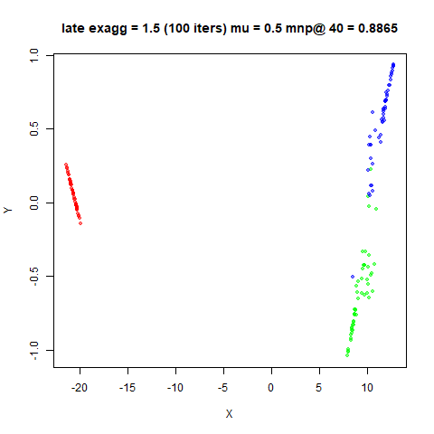

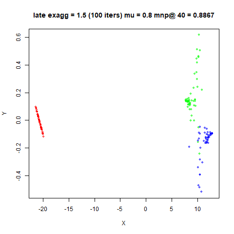

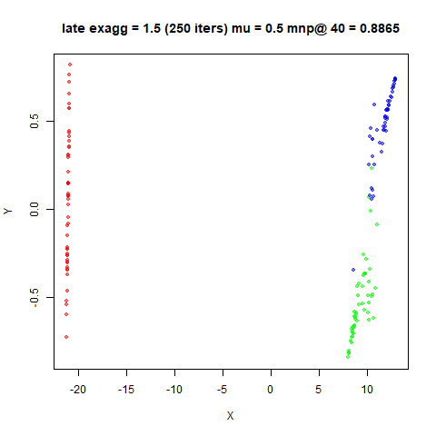

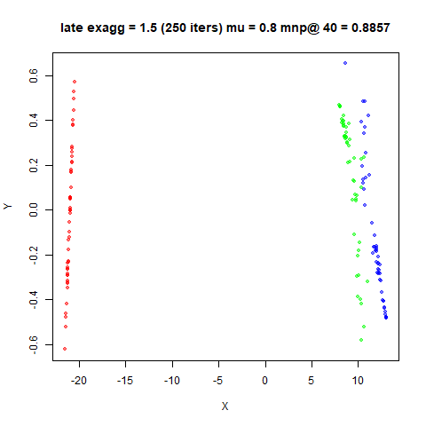

### s1k

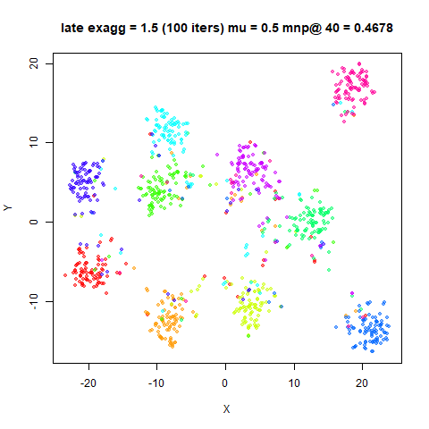

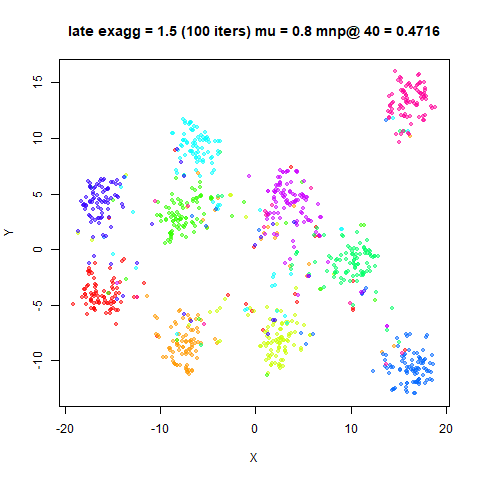

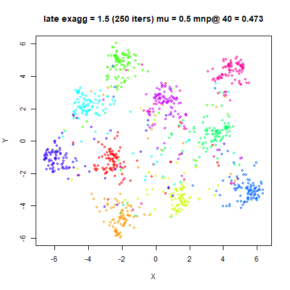

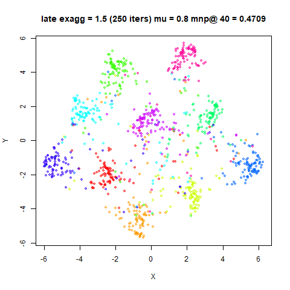

### oli

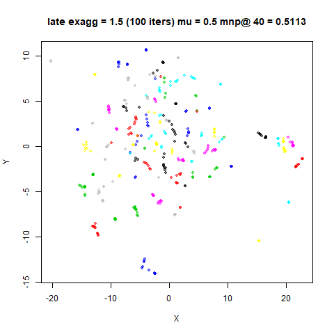

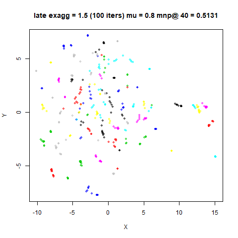

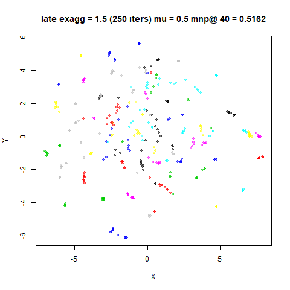

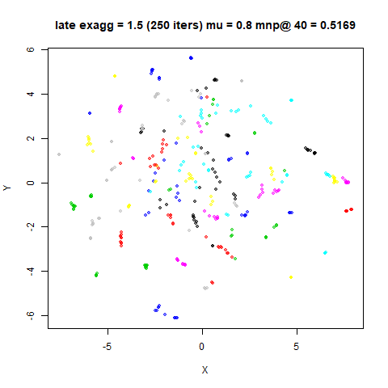

### frey

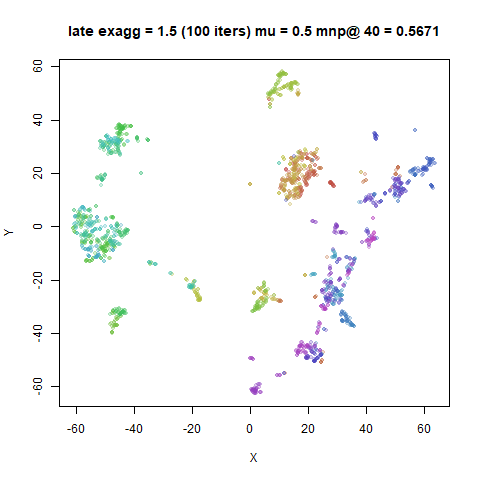

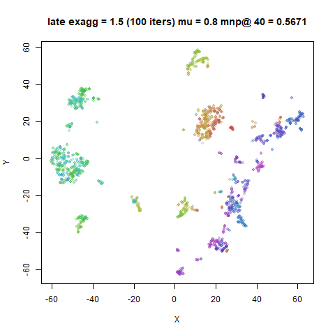

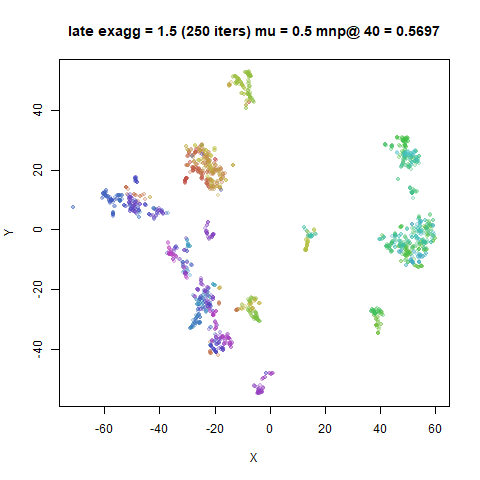

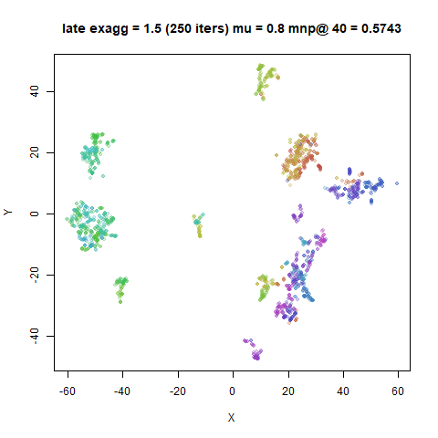

### coil20

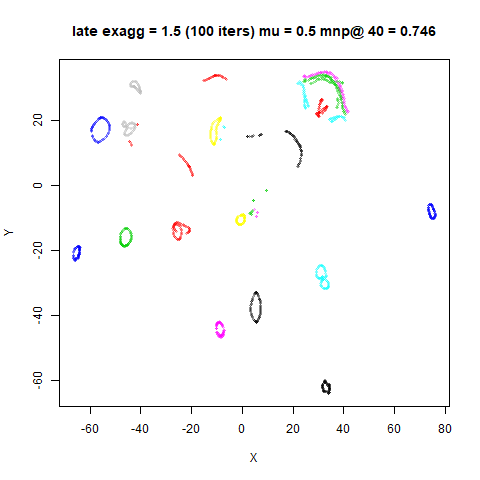

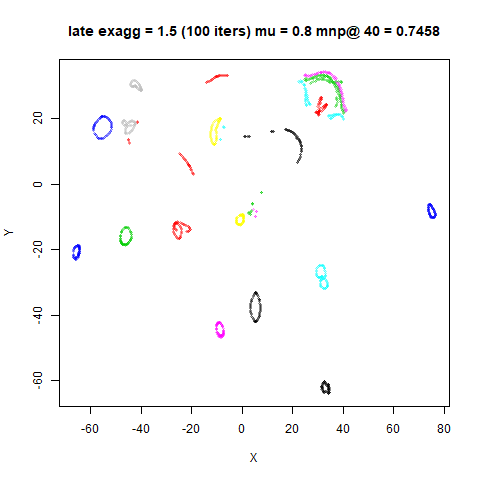

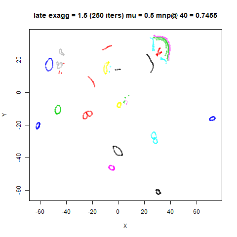

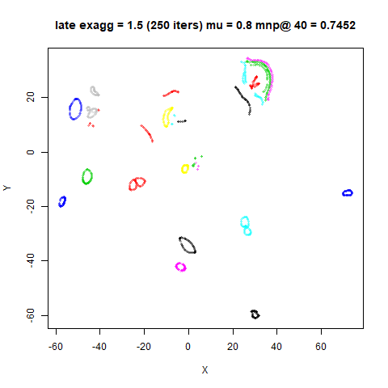

### mnist6k

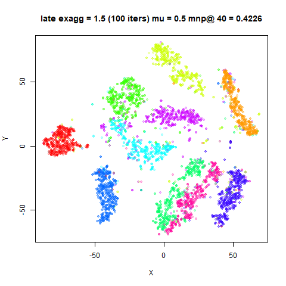

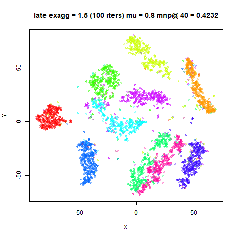

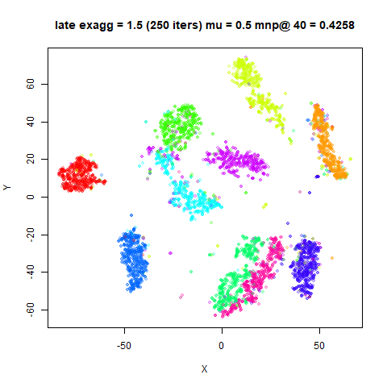

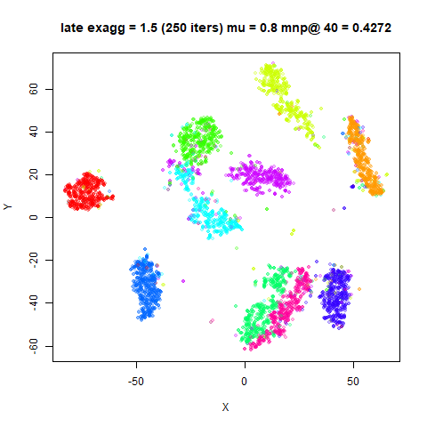

### fashion6k

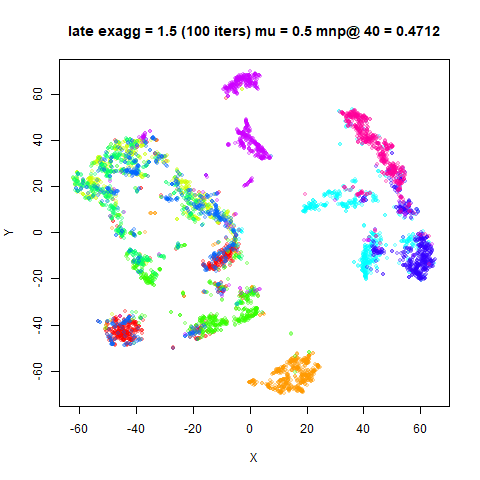

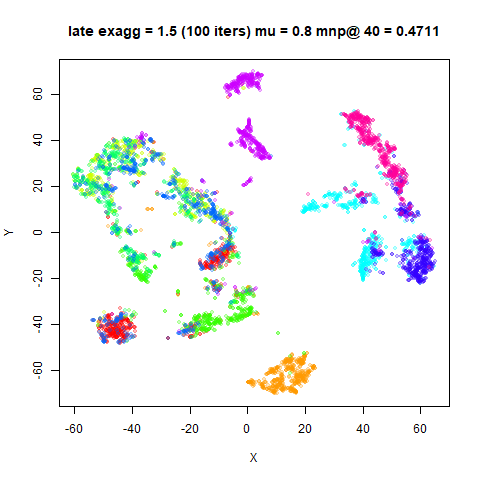

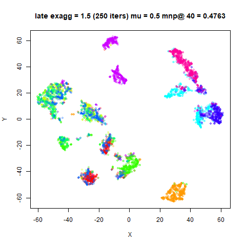

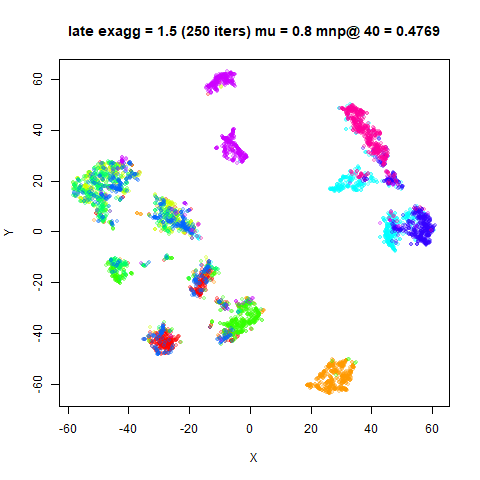

For the larger datasets, the extra time in late exaggeration results in more compression of the clusters, but the change in momentum doesn’t seem to do very much. And neighbor preservations aren’t affected. That’s good because reducing the momentum this would introduce coupling between the optimizer and the exaggeration code, which is not something I relish.

If you want to try late exaggeration, my recommendations remain the same: set `late_exaggeration_factor = 1.5`, and you probably don’t need more than 100 iterations.

*May 6 2020*: Dmitry Kobak notes that the late exaggeration protocol described in the [FIt-SNE preprint](https://arxiv.org/abs/1712.09005) and replicated here does not appear in its final published form in [Nature Methods](https://doi.org/10.1038/s41592-018-0308-4). A modified protocol (called just “exaggeration”) was published by Dmitry and Philipp Berens in [The art of using t-SNE for single-cell transcriptomics](https://dx.doi.org/10.1038%2Fs41467-019-13056-x) and recommends immediately beginning late exaggeration as soon as early exaggeration finishes, so you might want to consider that.

## Acknowledgement

Thank you to Dmitry Kobak, who drew my attention to the similarity between UMAP/LargeVis results and the output of late exaggeration, prompting me to implement it in `smallvis`.

Up: [Documentation Home](https://jlmelville.github.io/smallvis/).